# Project Description

In this project, we will study online shopping behavior by comparing **returning customers** with **new customers** using basic statistics and probability techniques. Our goal is to understand how these two groups behave differently when browsing the website and making purchases. The insights we gain will help the marketing team better understand customer engagement on the website.

Online shopping decisions often depend on how customers interact with a store's content. To explore this, we will analyze a dataset that contains information about online shopping sessions collected over the past year. We will focus especially on sessions from **November and December**, which are usually the busiest months for online shopping.

After identifying these two groups, we will estimate the probability that each type of customer will make a purchase during a future marketing campaign. This information will be useful for planning next year’s sales strategy and improving campaign effectiveness.

## Dataset Description

We are using a dataset named `online_shopping_session_data.csv`. Each row represents a single online shopping session. The dataset includes information about what pages were visited, how long users stayed on certain sections, and whether they made a purchase.

Below is a description of the main columns in the dataset:

| Column | Description |
| --- | --- |
| `SessionID` | A unique ID for each shopping session |
| `Administrative` | Number of pages visited related to customer account settings or admin-related features |
| `Administrative_Duration` | Total time (in seconds) spent on administrative pages |
| `Informational` | Number of pages viewed that provide information about the website or company |
| `Informational_Duration` | Total time (in seconds) spent on informational pages |
| `ProductRelated` | Number of product-related pages visited |
| `ProductRelated_Duration` | Total time (in seconds) spent on product-related pages |
| `BounceRates` | The average bounce rate (when customers leave after viewing one page) during the session |
| `ExitRates` | The average rate at which users exit from the pages they visit |
| `PageValues` | A value score for the pages visited, based on previous user activity and conversions |
| `SpecialDay` | How close the session date is to a special shopping day (like Black Friday) |
| `Weekend` | Whether the session occurred on a weekend (True or False) |
| `Month` | The month in which the session took place |
| `CustomerType` | Indicates whether the customer is a returning visitor or a new visitor |
| `Purchase` | Indicates whether a purchase was made in the session (True or False) |

By using this data, we will apply statistical analysis and probability models to make predictions about customer behavior. This will help us answer important questions like:

- Which group is more likely to make a purchase?
- What patterns can we observe during high shopping months?
- How should we design future marketing campaigns for different customer types?

This project will strengthen our ability to work with real-world data and apply staistical thinking to solve business problems.

```python
# Import required libraries
import pandas as pd
import numpy as np
import matplotlib.pyplot as plt
from scipy import stats

# Load and preview data
shopping_data = pd.read_csv("online_shopping_session_data.csv")
shopping_data.head()
```

|  | SessionID | Administrative | Administrative_Duration | Informational | Informational_Duration | ProductRelated | ProductRelated_Duration | BounceRates | ExitRates | PageValues | SpecialDay | Weekend | Month | CustomerType | Purchase |
| --- | --- | --- | --- | --- | --- | --- | --- | --- | --- | --- | --- | --- | --- | --- | --- |
| 0 | 1 | 0 | 0.0 | 0 | 0.0 | 1 | 0.000000 | 0.20 | 0.20 | 0.0 | 0.0 | False | Feb | Returning_Customer | 0.0 |
| 1 | 2 | 0 | 0.0 | 0 | 0.0 | 2 | 64.000000 | 0.00 | 0.10 | 0.0 | 0.0 | False | Feb | Returning_Customer | 0.0 |
| 2 | 3 | 0 | 0.0 | 0 | 0.0 | 1 | 0.000000 | 0.20 | 0.20 | 0.0 | 0.0 | False | Feb | Returning_Customer | 0.0 |
| 3 | 4 | 0 | 0.0 | 0 | 0.0 | 2 | 2.666667 | 0.05 | 0.14 | 0.0 | 0.0 | False | Feb | Returning_Customer | 0.0 |
| 4 | 5 | 0 | 0.0 | 0 | 0.0 | 10 | 627.500000 | 0.02 | 0.05 | 0.0 | 0.0 | True | Feb | Returning_Customer | 0.0 |

### What are the purchase rates for online shopping sessions by customer type for November and December?

```python
# Subset dataframe for November and December data
shopping_Nov_Dec = shopping_data[shopping_data['Month'].isin(['Nov', 'Dec'])]

# Preview to make sure the subset is correct
shopping_Nov_Dec.head()
```

|  | SessionID | Administrative | Administrative_Duration | Informational | Informational_Duration | ProductRelated | ProductRelated_Duration | BounceRates | ExitRates | PageValues | SpecialDay | Weekend | Month | CustomerType | Purchase |
| --- | --- | --- | --- | --- | --- | --- | --- | --- | --- | --- | --- | --- | --- | --- | --- |
| 5463 | 5464 | 1 | 39.2 | 2 | 120.8 | 7 | 80.500000 | 0.000000 | 0.010000 | 0.000000 | 0.0 | True | Nov | New_Customer | 0.0 |
| 5464 | 5465 | 3 | 89.6 | 0 | 0.0 | 57 | 1721.906667 | 0.000000 | 0.005932 | 204.007949 | 0.0 | True | Nov | Returning_Customer | 1.0 |
| 5467 | 5468 | 4 | 204.2 | 0 | 0.0 | 31 | 652.376667 | 0.012121 | 0.016162 | 0.000000 | 0.0 | False | Nov | Returning_Customer | 0.0 |
| 5479 | 5480 | 0 | 0.0 | 0 | 0.0 | 13 | 710.066667 | 0.000000 | 0.007692 | 72.522838 | 0.0 | False | Nov | Returning_Customer | 1.0 |
| 5494 | 5495 | 0 | 0.0 | 0 | 0.0 | 24 | 968.692424 | 0.000000 | 0.000000 | 106.252517 | 0.0 | False | Nov | Returning_Customer | 1.0 |

```python
# Make sure we only have November and December data
shopping_Nov_Dec['Month'].unique()
```

```
array(['Nov', 'Dec'], dtype=object)
```

```python
# Get session frequency stats by CustomerType and Purchase
count_session = shopping_Nov_Dec.groupby(['CustomerType'])['Purchase'].value_counts()
count_session
```

```
CustomerType        Purchase
New_Customer        0.0          529
                    1.0          199
Returning_Customer  0.0         2994
                    1.0          728
Name: count, dtype: int64
```

```python
# Total number of session by CustomerType
total_new_customer = np.sum(count_session['New_Customer'])
total_returning_customer = np.sum(count_session['Returning_Customer'])


# Total number of purchase by CustomerType
purchase_new_customer = count_session[('New_Customer', 1)]
purchase_returning_customer = count_session[('Returning_Customer', 1)]


# Calculate purchase rates
purchase_rate_new = purchase_new_customer / total_new_customer
purchase_rate_returning = purchase_returning_customer / total_returning_customer


# view the results
purchase_rates = {"Returning_Customer": purchase_rate_returning, "New_Customer": purchase_rate_new}
purchase_rates
```

```
{'Returning_Customer': 0.1955937667920473, 'New_Customer': 0.2733516483516483}
```

```python
# Calculate correlation with pandas
cor_admin_info = shopping_Nov_Dec['Administrative_Duration'].corr(shopping_Nov_Dec['Informational_Duration'])
cor_admin_product = shopping_Nov_Dec['Administrative_Duration'].corr(shopping_Nov_Dec['ProductRelated_Duration'])
cor_product_info = shopping_Nov_Dec['ProductRelated_Duration'].corr(shopping_Nov_Dec['Informational_Duration'])

print(cor_admin_info)
print(cor_admin_product)
print(cor_product_info)
```

```
0.2446885579283925
0.38985460032069624
0.36712552534442094
```

```python
# Store top correlation
top_correlation = {"pair": ('Administrative_Duration', 'ProductRelated_Duration'), "correlation": cor_admin_product}
print(top_correlation)
```

```
{'pair': ('Administrative_Duration', 'ProductRelated_Duration'), 'correlation': 0.38985460032069624}
```

### A new campaign for the returning customers will boost the purchase rate by 15%. What is the likelihood of achieving at least 100 sales out of 500 online shopping sessions for the returning customers?

```python
# We know that the current purchase rate for the returning customers is
print("Current purchase rate for the returning customer:", purchase_rate_returning)
```

```
Current purchase rate for the returning customer: 0.1955937667920473
```

```python
# 15% Increase in this rate would be
increased_purchase_rate_returning = 1.15 * purchase_rate_returning
print("Increased purchase rate for the returning customer:", increased_purchase_rate_returning)
```

```
Increased purchase rate for the returning customer: 0.22493283181085436
```

```python
#  likelihood of having <100 sales of 500 sessions
prob_sales_100_less = stats.binom.cdf(k=100, n=500, p=increased_purchase_rate_returning)
print("probability of having <100 sales:", prob_sales_100_less)
```

```
probability of having <100 sales: 0.09877786609627338
```

```python
# probability of having 100 or more sales is 1-prob_sales_100_less
prob_at_least_100_sales = 1 - prob_sales_100_less
print("probability of having at least 100 sales:", prob_at_least_100_sales)
```

```
probability of having at least 100 sales: 0.9012221339037266
```

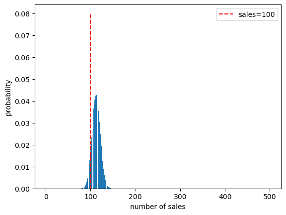

```python
# Plotting the binomial probability distribution
n_sessions = 500
k_values = np.arange(500) + 1
p_binom_values = [stats.binom.pmf(k, n_sessions, increased_purchase_rate_returning) for k in k_values ]
plt.bar(k_values, p_binom_values)
plt.vlines(100, 0, 0.08, color='r', linestyle='dashed', label="sales=100")
plt.xlabel("number of sales")
plt.ylabel("probability")
plt.legend()
plt.show()
```